# Praca domowa #5

Małgorzata Wachulec

29/04/2019

# 1 Wstęp

W tej pracy domowej omówiony będzie model ranger z pakietu mlr (modelu z właśnie tej biblioteki użyto w artykule). Porównane zostaną wyniki na różnych zestawach hiperparametrów: tych domyślnych, tych z artykułu oraz tych zoptymalizowanych przy użyciu random search, dla zbioru danych titanic. Hiperparametry modelu ranger, o których mowa w artykule to num.trees - liczba drzew decyzyjnych, replace - wartość logiczna informująca o tym czy losujemy ze zwracaniem, sample.fraction - z jakiej części obserwacji losujemy, mtry - liczba zmiennych, którą bierzemy pod uwagę przy rozgałęzieniu drzewa oraz min.node.size - minimalny rozmiar węzła, zazwyczaj równy 1 dla klasyfikacji.

Ze zbioru danych Titanic wycięte zostały kolumny zawierające informacje o imieniu, nazwisku, id pasażera, a także kolumny Ticket i Cabin jako, że nie powinny mieć wpływu na model lub nie zawierały istotnych informacji.

# 2 Skuteczność rangera z hiperparametrami z artykułu

Wartości miar acc, auc i f1, uzyskanych za pomocą kroswalidacji to:

```r
task <- makeClassifTask(id = "task", data = dataset, target = "Survived")
article <- makeLearner("classif.ranger", predict.type = "prob", par.vals = list(num.trees = 983,
                                                                                replace = FALSE,
                                                                                sample.fraction = 0.703,
                                                                                mtry = 1,
                                                                                min.node.size = 1))
cv <- makeResampleDesc("CV", iters = 5)
ra <- resample(article, task, cv,measures = list(mlr::acc, mlr::auc, mlr::f1),show.info = FALSE)
ra$aggr
```

```
## acc.test.mean auc.test.mean  f1.test.mean
##     0.8095144     0.8652726     0.8512201
```

Dla porównania zobaczmy jak sprawdziły się hiperparametry domyślne i te otrzymane poprzez użycie random search.

# 3 Porównanie z rangerem z domyślnymi hiperparametrami i z wynikiem random search

Dla hiperparametrów domyślnych mamy:

```r
default <- makeLearner("classif.ranger", predict.type = "prob")
rd <- resample(default, task, cv,measures = list(mlr::acc, mlr::auc, mlr::f1),show.info = FALSE)
rd$aggr
```

```
## acc.test.mean auc.test.mean  f1.test.mean
##     0.8150990     0.8690000     0.8522782
```

Dla hiperparametrów wybranych dzięki random search z 200 iteracjami mamy:

```r
#ranger_pars <- tuneParams(
#  makeLearner("classif.ranger",predict.type = "prob"),
#  subsetTask(makeClassifTask(id = "task", data = dataset, target = "Survived")),
#  resampling = cv5,
#  measures = mlr::auc,
#  par.set = makeParamSet(
#    makeDiscreteParam("num.trees", values = 1:1000),
#    makeLogicalParam("replace"),
#    makeNumericParam("sample.fraction", lower = 0, upper = 1),
#    makeDiscreteParam("mtry", values = 1:5),
#    makeDiscreteParam("min.node.size", values = 1:10)
#  ),
#  control = makeTuneControlRandom(maxit = 200)
#)
#saveRDS(ranger_pars,file="ranger_pars")
ranger_pars <- readRDS("ranger_pars")
tuned <- makeLearner("classif.ranger",predict.type = "prob",par.vals = ranger_pars$x)
rt <- resample(tuned, task, cv,measures = list(mlr::acc, mlr::auc, mlr::f1),show.info = FALSE)
rt$aggr
```

```
## acc.test.mean auc.test.mean  f1.test.mean
##     0.8193243     0.8612001     0.8558508
```

Auc uzyskane dla modelu domyślnego jest najwyższe z dotychczasowych, jednakże nie istnieją jeszcze pakiety, które umożliwiałyby narysowanine drzewa decyzyjnego tego modelu. By móc rozwiązać 3 i 4 podpunkt zadania domowego, muszę ponownie sprawdzić powyższe zależności, tym razem dla modelu rpart, który pozwala na wyświetlenie drzewa.

# 4 Porównanie modelu rpart z różnymi hiperparametrami

```r
# learners
rpart_default<-makeLearner("classif.rpart",predict.type = "prob")
rpart_article<-makeLearner("classif.rpart",predict.type = "prob",par.vals = list(cp=0,maxdepth=21,minbucket=12,minsplit=24))

#rpart_pars <- tuneParams(
#  makeLearner("classif.rpart",predict.type = "prob"),
#  subsetTask(makeClassifTask(id = "task", data = dataset, target = "Survived")),
#  resampling = cv5,
#  measures = mlr::auc,
#  par.set = makeParamSet(
#    makeNumericParam("cp",lower = 0,upper = 1),
#    makeDiscreteParam("maxdepth", values = 1:30),
#    makeDiscreteParam("minbucket", values = 1:50),
#    makeDiscreteParam("minsplit", values = 1:50)
#  ),
#  control = makeTuneControlRandom(maxit = 200)
#)
#saveRDS(rpart_pars,file="rpart_pars")
rpart_pars <- readRDS("rpart_pars")
rpart_tuned <- makeLearner("classif.rpart",predict.type = "prob",par.vals = rpart_pars$x)

# resampling
rpart_ra <- resample(rpart_article, task, cv,measures = list(mlr::acc, mlr::auc, mlr::f1),show.info = FALSE)
rpart_rd <- resample(rpart_default, task, cv,measures = list(mlr::acc, mlr::auc, mlr::f1),show.info = FALSE)
rpart_rt <- resample(rpart_tuned, task, cv,measures = list(mlr::acc, mlr::auc, mlr::f1),show.info = FALSE)
```

Wyniki modelu rpart dla hiperparametrów, które zasugerowano w artykule:

```r
rpart_ra$aggr
```

```
## acc.test.mean auc.test.mean  f1.test.mean
##     0.7800355     0.8476103     0.8233742
```

Wyniki modelu rpart dla hiperparametrów domyślnych:

```r
rpart_rd$aggr
```

```
## acc.test.mean auc.test.mean  f1.test.mean
##     0.7941397     0.8258834     0.8343851
```

Wyniki modelu rpart po tunningu hiperparametrów:

```r
rpart_rt$aggr
```

```
## acc.test.mean auc.test.mean  f1.test.mean
##     0.7787452     0.7880543     0.8273972
```

Najlepsze okazały się być hiperparametry wskazane w artykule.

# 5 Najlepsze drzewo

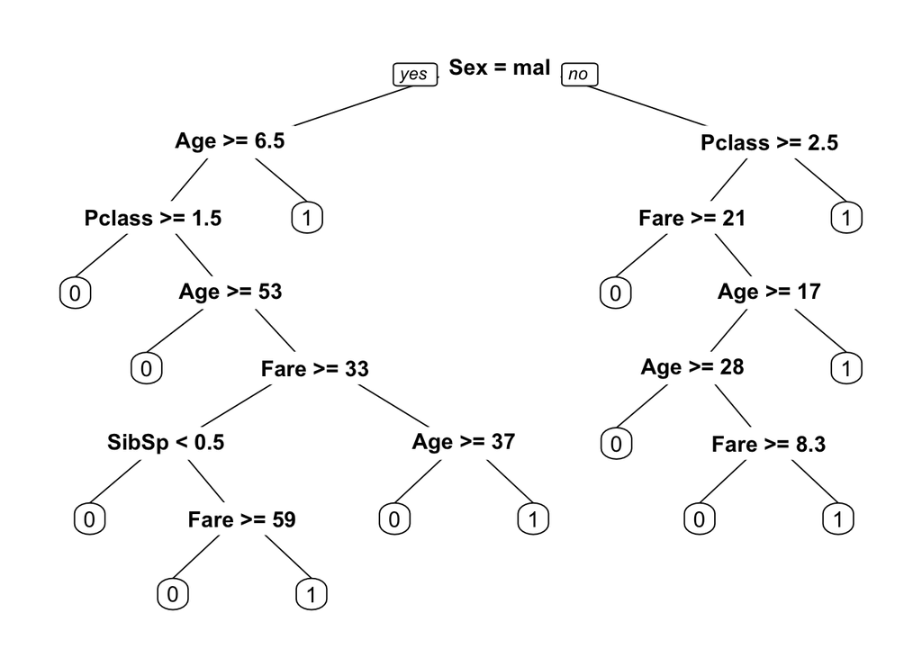

```r
best <- train(rpart_article,task)
prp(best$learner.model, roundint = FALSE)
```

Warto zauważyć, że w powyższym drzewie wartości spełniające warunek w węźle znajdują się na lewo od niego, a te, które go nie spełniają - na prawo od niego. Wartości 0 i 1 widoczne na liściach tego drzewa to przypisana wartość kolumny Survived, którą przewidujemy. Możemy teraz zauważyć, że zmienne Parch i Embarked nie miały wpływu na ten model, a zmienna Sex była tu najistotniejsza.

# 6 Podział Gini i Information Gain

Podział metodą Gini jest domyślnym podziałem, więc aby porównać metody podziału Gini i Information Gain wystarczy utworzyć nowy model z metodą Information Gain i porównać jego wyniki z tym już utworzonym. Oba modele będą mieć hiperparametry wskazane w artykule.

Oto wyniki dla modelu rpart z metodą Information Gain:

```r
rpart_article_info <-makeLearner("classif.rpart",predict.type = "prob",par.vals = list(parms = list(split = 'information'),cp=0,maxdepth=21,minbucket=12,minsplit=24))
rpart_ra_info <- resample(rpart_article_info, task, cv,measures = list(mlr::acc, mlr::auc, mlr::f1),show.info = FALSE)
rpart_ra_info$aggr
```

```
## acc.test.mean auc.test.mean  f1.test.mean
##     0.7885748     0.8363953     0.8306662
```

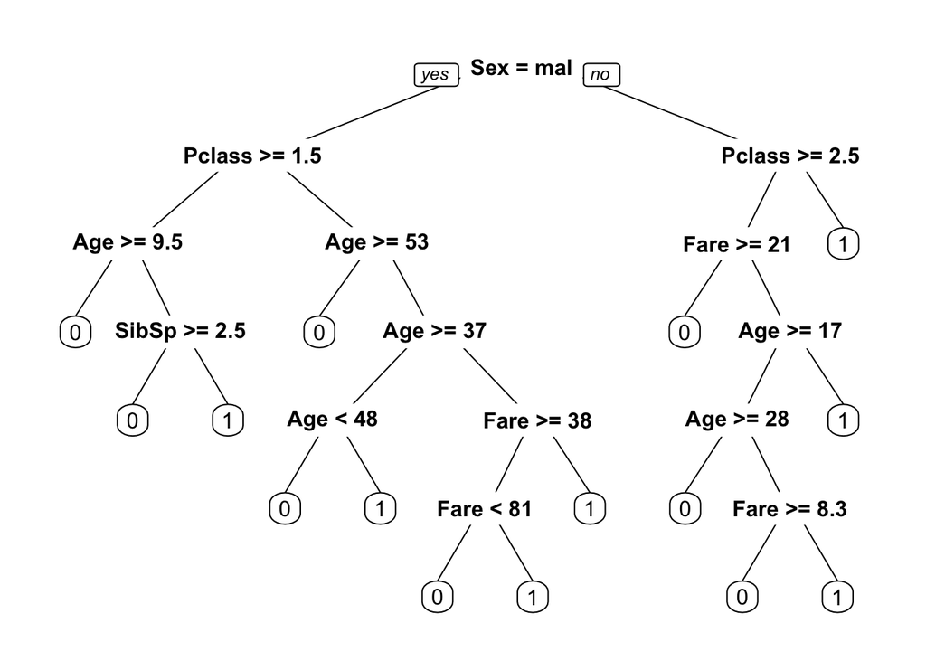

```r
info <- train(rpart_article_info,task)
prp(info$learner.model, roundint = FALSE)
```

Możemy zauważyć różnice, w kolejności występowania niektórych warunków, np. dla mężczyzn w poprzednim modelu kolejnym warunkiem był wiek, a w tym modelu jest to klasa, którą podróżowali. Dalej jednak najważniejszą zmienną jest kolumna Sex, a zmienne Parch i Embarked nadal są nieistotne.